# Homework 1.2

Ettore Puccetti, Lorenzo Foà, Mehdi El Idrissi, Boris Mattijssen

## Introduction

For homewrok 1.2.1 we chose the cars (Cars) dataset which contains informations about cars commercialized between year 1970 and 1977. At the beginning (a) we will explore the distribution of the variable miles per gallon (mpg) in terms of descriptive measures of center, dispersion, skewness and kurtosis, then we will check the normality and, if this condition is absent, we will try to improve data’s normality by applying some transformations. After this we will describe (b) the joint bivariate distribution of the variables car weight and car accelartion. We will again check the normality and look for outliers. Lastly we will pick (c) a subset of 4 or 5 quantitative variables for exploring the linear relationships through the following methods:R matrix of pairwise correlations, matrix of partial correlations, coefficient of determination, the determinant of the correlation matrix R and an eigenanalysis of matrix R.

In homework 1.2.2 we used the Restaurant Tips dataset, where are stored informations about the restaurant bills. The purpose of the analysis is to see if there is evidence of a consistent relationship between the size of the bill and the percent tip.

## Descriptive analysis

In this section we will perform a descriptive analysis of the cars dataset. The dataset contains information about different car models such as, miles per gallon, number of cylinders, horsepower, etc.

The section is structured as follows. Firstly, we perform a univariate analysis on the `mpg` variable. Then, a bivariate analysis is performed on the combined variable (`weight`,`acceleration`). Lastly, we have a look at the interaction between a subset of five variables in the dataset.

```r
library(ggplot2)
library(moments)
library(stats)
library(corrplot)
library(MVN)
library(car)
library(ppcor)
library(corrgram)
library(corrplot)
```

```r
cars = read.delim("cars.txt", sep = "", dec = ".")
head(cars)
```

|  | mpg | cylinders | displacement | horsepower | weight | acceleration | year | origin | name |
| --- | --- | --- | --- | --- | --- | --- | --- | --- | --- |
| 1 | 18 | 8 | 307 | 130 | 3504 | 12.0 | 70 | 1 | chevrolet chevelle malibu |
| 2 | 15 | 8 | 350 | 165 | 3693 | 11.5 | 70 | 1 | buick skylark 320 |
| 3 | 18 | 8 | 318 | 150 | 3436 | 11.0 | 70 | 1 | plymouth satellite |
| 4 | 16 | 8 | 304 | 150 | 3433 | 12.0 | 70 | 1 | amc rebel sst |
| 5 | 17 | 8 | 302 | 140 | 3449 | 10.5 | 70 | 1 | ford torino |
| 6 | 15 | 8 | 429 | 198 | 4341 | 10.0 | 70 | 1 | ford galaxie 500 |

### Distribution of miles per gallon (mpg)

We are going to explore the `mpg` variable.

#### Asserting normality

To get a sense of how this data looks we will plot it in a histogram. Then, we will use the following descriptive statistics to describe the data: mean, standard deviation, skewness, and kurtosis.

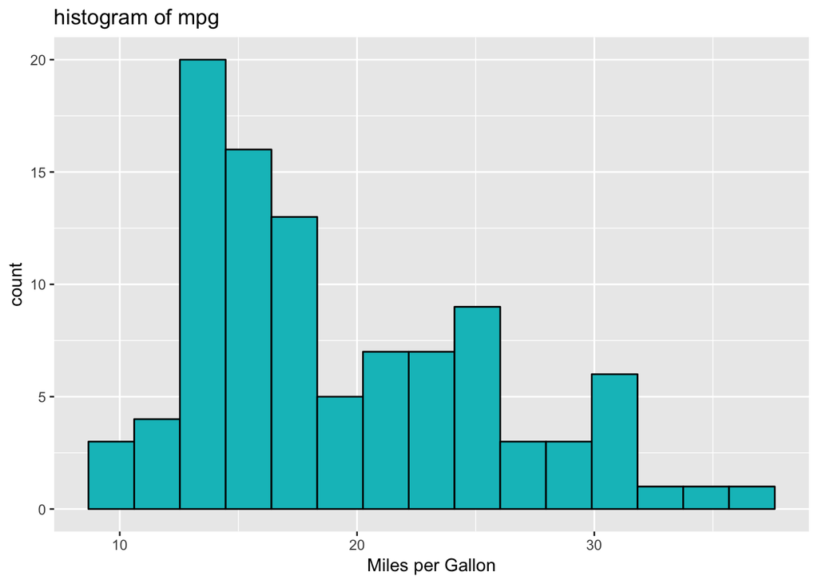

```r
ggplot(cars, aes(x=cars$mpg)) +
  geom_histogram(fill='#00BFC4', color="black", bins = 15) +
  xlab("Miles per Gallon") +
  ggtitle("histogram of mpg", subtitle = NULL)
```

```r
mean(cars$mpg)
```

```
## [1] 19.34848
```

```r
sd(cars$mpg)
```

```
## [1] 6.322318
```

```r
skewness(cars$mpg)
```

```
## [1] 0.6609693
```

```r
kurtosis(cars$mpg)
```

```
## [1] 2.523248
```

The histogram shows that the data is not distributed normally. This is further supported by the descriptive statistics. The data is fairly right-tailed since the skewness is positive and far from zero (0.6609693). Furthermore, the kurtosis is 2.523248, which means the data is platykurtic (i.e. more compact than a normal distribution).

A more rigid approach to assert normality is to use a statistical test. In this case we choose Shapiro-Wilk’s test, because the sample size is not very large (i.e. 99 samples).

```r
shapiro.test(cars$mpg)
```

```
##
##  Shapiro-Wilk normality test
##
## data:  cars$mpg
## W = 0.93467, p-value = 0.0001004
```

Since the p-value is very low (0.0001), we reject the null-hypothesis and conclude that the data is indeed not normally distributed.

To see if there are any outliers, we use the `boxplot` function. It tells us that there are no outliers:

```r
boxplot(cars$mpg,plot=FALSE)$out
```

```
## numeric(0)
```

#### Improving normality

To improve the normality we use a Box-Cox transformation.

First, we find the power coefficients.

```r
summary(powerTransform(cars$mpg))
```

```
## bcPower Transformation to Normality
##          Est Power Rounded Pwr Wald Lwr Bnd Wald Upr Bnd
## cars$mpg    -0.245           0      -0.8618       0.3718
##
## Likelihood ratio test that transformation parameter is equal to 0
##  (log transformation)
##                             LRT df    pval
## LR test, lambda = (0) 0.6025055  1 0.43762
##
## Likelihood ratio test that no transformation is needed
##                            LRT df       pval
## LR test, lambda = (1) 15.13944  1 9.9855e-05
```

Then, we apply the Box-Cox power transform with $\lambda=-0.245$.

```r
cars$mpg_bc = bcPower(cars$mpg, -0.245)
```

The histogram and statistics now look as follows.

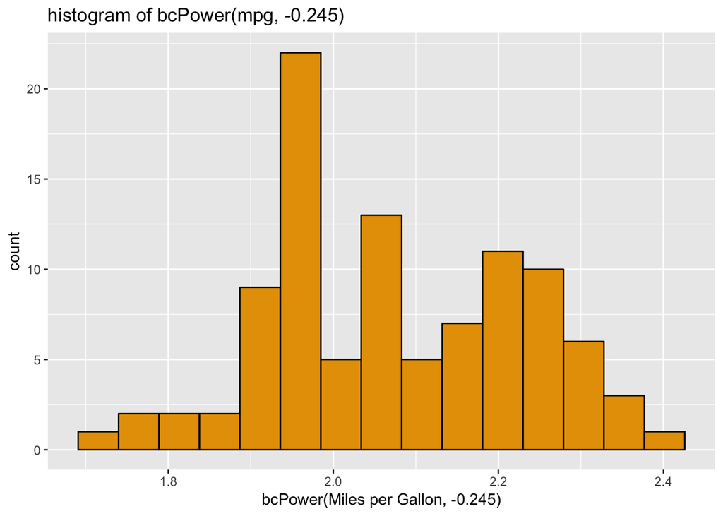

```r
ggplot(cars, aes(x=cars$mpg_bc)) +
  geom_histogram(fill='#E69F00', color="black", bins = 15) +
  xlab("bcPower(Miles per Gallon, -0.245)") +
  ggtitle("histogram of bcPower(mpg, -0.245)", subtitle = NULL)
```

```r
mean(cars$mpg_bc)
```

```
## [1] 2.075589
```

```r
sd(cars$mpg_bc)
```

```
## [1] 0.1560829
```

```r
skewness(cars$mpg_bc)
```

```
## [1] 0.02157166
```

```r
kurtosis(cars$mpg_bc)
```

```
## [1] 2.193362
```

```r
shapiro.test(cars$mpg_bc)
```

```
##
##  Shapiro-Wilk normality test
##
## data:  cars$mpg_bc
## W = 0.97143, p-value = 0.02976
```

We now observe a higher p-value, but we still reject the null-hypothesis because the p-value is lower than 0.05.

Again, using the `boxplot` function we note that there are no outliers.

```r
boxplot(cars$mpg_bc, plot=FALSE)$out
```

```
## numeric(0)
```

### Bivariate distribution of car weight and acceleration

Now we are going to describe the bivariate distribution of car weight and car accelartion. Let us start by showing the mean vector, covariance matrix, and a scatterplot of the data.

```r
bivar = cbind(cars$weight, cars$acceleration)
colMeans(bivar)
```

```
## [1] 3263.89899   14.70606
```

```r
cov(bivar)
```

```
##            [,1]        [,2]
## [1,] 926330.561 -1519.56163
## [2,]  -1519.562    10.02935
```

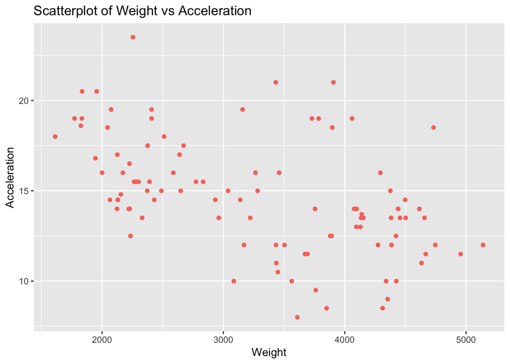

```r
ggplot(data=as.data.frame(bivar),aes(x=bivar[,1],y=bivar[,2])) +
  geom_point(color = "#F8766D")+
  xlab('Weight')+
  ylab('Acceleration') +
  ggtitle("Scatterplot of Weight vs Acceleration", subtitle = NULL)
```

By visual inspection it looks like the data is not normally distributed. To further test this intuition we will resort to `MVN` package for a variety of multivariate normality test: *mardia*, *hz*, and *royston*.

```r
mvn(bivar, mvnTest="mardia")$multivariateNormality
```

| Test | Statistic | p value | Result |
| --- | --- | --- | --- |
| Mardia Skewness | 5.56506132598297 | 0.234069455379992 | YES |
| Mardia Kurtosis | -1.9175188628952 | 0.0551720469329795 | YES |
| MVN | NA | NA | YES |

```r
mvn(bivar, mvnTest="hz")$multivariateNormality
```

| Test | HZ | p value | MVN |
| --- | --- | --- | --- |
| Henze-Zirkler | 2.65141 | 2.678342e-06 | NO |

```r
mvn(bivar, mvnTest="royston")$multivariateNormality
```

| Test | H | p value | MVN |
| --- | --- | --- | --- |
| Royston | 15.48174 | 0.0003795107 | NO |

Both Henze-Zirkler’s MVN test and Royston’s MVN test tell use that the data is not normally distributed, whereas Mardia’s MVN test suggests the opposite. It could therefore be informative to look at the Q-Q plot.

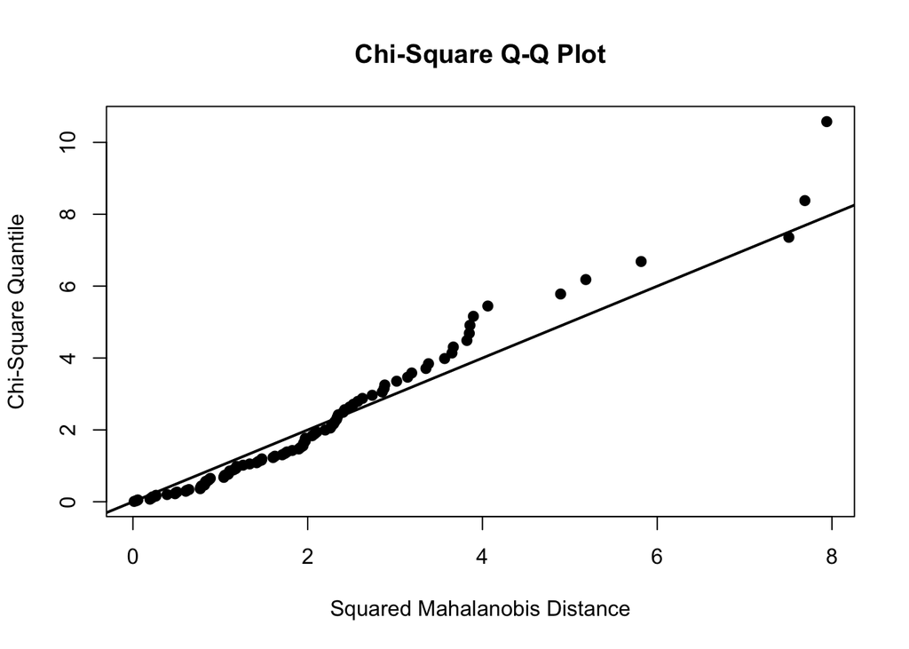

```r
invisible(mvn(data = bivar, mvnTest="mardia", multivariatePlot="qq"))
```

In the Q-Q plot we see that the residuals start to diverge from the straight line, which also suggest that the data is *not* normally distributed. Combining all the evidence, it seems most likely that the data is not normally distributed.

In an attempt to improve normality by using a Box-Cox transformation we observe no improvements. This is shown by the following code.

Firstly, we find the power coefficients.

```r
summary(powerTransform(bivar~1))
```

```
## bcPower Transformations to Multinormality
##    Est Power Rounded Pwr Wald Lwr Bnd Wald Upr Bnd
## Y1    0.4528           1      -0.2875       1.1931
## Y2    0.5140           1      -0.2009       1.2288
##
## Likelihood ratio test that transformation parameters are equal to 0
##  (all log transformations)
##                              LRT df    pval
## LR test, lambda = (0 0) 3.493608  2 0.17433
##
## Likelihood ratio test that no transformations are needed
##                              LRT df    pval
## LR test, lambda = (1 1) 3.792314  2 0.15014
```

Secondly, we apply the Box-Cox power transform with ($\lambda_1=0.4528$, $_2=0.514 $).

```r
bivar_cb = bcPower(bivar, c(0.4528,0.514))
```

Lastly, we apply the MVN tests on the transformed variable.

```r
mvn(bivar_cb, mvnTest="mardia")$multivariateNormality
```

| Test | Statistic | p value | Result |
| --- | --- | --- | --- |
| Mardia Skewness | 4.57468680130256 | 0.333783186480036 | YES |
| Mardia Kurtosis | -1.9841875559756 | 0.0472349352751809 | NO |
| MVN | NA | NA | NO |

```r
mvn(bivar_cb, mvnTest="hz")$multivariateNormality
```

| Test | HZ | p value | MVN |
| --- | --- | --- | --- |
| Henze-Zirkler | 2.420048 | 9.011161e-06 | NO |

```r
mvn(bivar_cb, mvnTest="royston")$multivariateNormality
```

| Test | H | p value | MVN |
| --- | --- | --- | --- |
| Royston | 14.84995 | 0.0005128113 | NO |

Lastly, we check if there are any outliers in the bivariate data. For this we use the `multivariateOutlierMethod = "quan"` argument to the `mvn` function. It will select all points with a Mahalanobis distance larger than the 97.5% quantile of the chi-square distribution as an outlier.

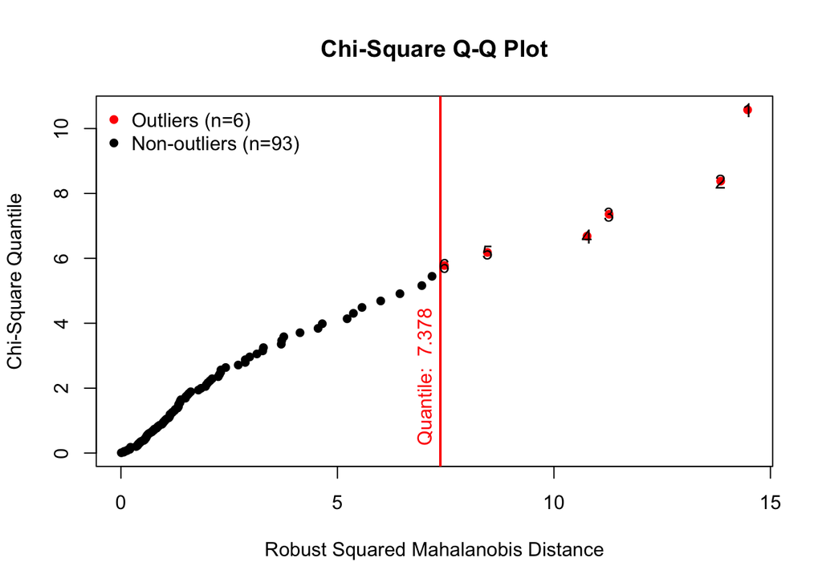

```r
invisible(mvn(data = as.data.frame(bivar), mvnTest = "hz", multivariateOutlierMethod = "quan"))
```

From the plot we see that there are six outliers in the bivariate dataset.

### Linear relationships

In this section we will explore the linear relationships for a subset of the data. In particular, we consider the following variables: mpg, displacement, horsepower, weight, and acceleration.

```r
cars_sub = cars[,c('mpg', 'displacement', 'horsepower', 'weight', 'acceleration')]
```

#### Covariance and Correlation matrix

```r
cov(cars_sub)
```

```
##                       mpg displacement horsepower     weight acceleration
## mpg             39.971707    -652.5315  -232.8480  -5490.924     9.505519
## displacement  -652.531463   14059.2749  4934.5437 104179.994  -255.431803
## horsepower    -232.848021    4934.5437  2117.8963  37334.261  -108.582406
## weight       -5490.923624  104179.9943 37334.2612 926330.561 -1519.561626
## acceleration     9.505519    -255.4318  -108.5824  -1519.562    10.029351
```

```r
r=cor(cars_sub)
r
```

```
##                     mpg displacement horsepower     weight acceleration
## mpg           1.0000000   -0.8704496 -0.8002835 -0.9023729    0.4747480
## displacement -0.8704496    1.0000000  0.9043014  0.9128930   -0.6802321
## horsepower   -0.8002835    0.9043014  1.0000000  0.8428926   -0.7450248
## weight       -0.9023729    0.9128930  0.8428926  1.0000000   -0.4985387
## acceleration  0.4747480   -0.6802321 -0.7450248 -0.4985387    1.0000000
```

We just displayed below the R-matrix. We can visualize it with a plot showing the correlation between the variables in a more intuitive way :

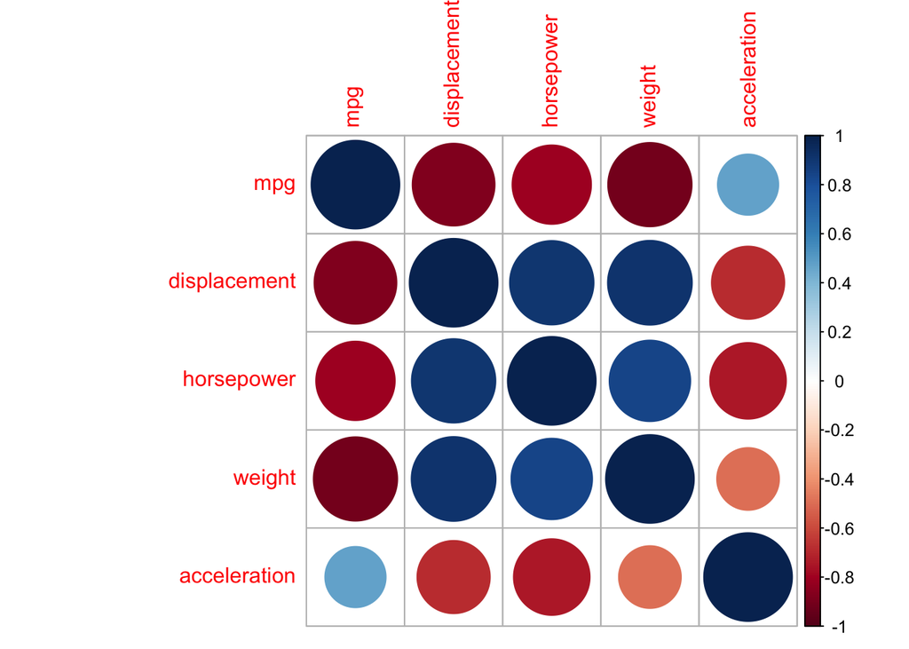

```r
corrplot(r, method = "circle")
```

Which variables are correlated the most ?

```r
diag(r)=0
which(r==max(abs(r)), arr.ind=TRUE)
```

```
##              row col
## weight         4   2
## displacement   2   4
```

The most correlated variables are weight and displacement which is logical because physically, displacement is strongly related to the car’s weight. Indeed, the correlation between these two variables is: 0.9128930 which is very high. We have a very strong linear relationship which implies that variables are measuring almost the same thing. Furthermore, almost all absolute correlations are high, apart from the acceleration-weight (0.4985387) and the acceleration-mpg (0.4747480) correlation.

#### Partial correlations

Let’s explore the relationship between our 5 variables through partial correlations :

```r
pcor(cars_sub)
```

```
## $estimate
##                      mpg displacement  horsepower     weight acceleration
## mpg           1.00000000   -0.2518629 -0.09316666 -0.4265432   -0.1651799
## displacement -0.25186293    1.0000000  0.27382566  0.5160035   -0.3932440
## horsepower   -0.09316666    0.2738257  1.00000000  0.2526219   -0.5084560
## weight       -0.42654320    0.5160035  0.25262188  1.0000000    0.3735432
## acceleration -0.16517990   -0.3932440 -0.50845604  0.3735432    1.0000000
##
## $p.value
##                       mpg displacement   horsepower       weight
## mpg          0.000000e+00 1.330641e-02 3.666049e-01 1.468146e-05
## displacement 1.330641e-02 0.000000e+00 6.942485e-03 7.419376e-08
## horsepower   3.666049e-01 6.942485e-03 0.000000e+00 1.302182e-02
## weight       1.468146e-05 7.419376e-08 1.302182e-02 0.000000e+00
## acceleration 1.077708e-01 7.387916e-05 1.231097e-07 1.777786e-04
##              acceleration
## mpg          1.077708e-01
## displacement 7.387916e-05
## horsepower   1.231097e-07
## weight       1.777786e-04
## acceleration 0.000000e+00
##
## $statistic
##                     mpg displacement horsepower    weight acceleration
## mpg           0.0000000    -2.523244 -0.9072303 -4.572294    -1.623784
## displacement -2.5232438     0.000000  2.7603403  5.840438    -4.146727
## horsepower   -0.9072303     2.760340  0.0000000  2.531365    -5.724925
## weight       -4.5722938     5.840438  2.5313646  0.000000     3.904253
## acceleration -1.6237837    -4.146727 -5.7249254  3.904253     0.000000
##
## $n
## [1] 99
##
## $gp
## [1] 3
##
## $method
## [1] "pearson"
```

```r
matrix.partial=pcor(cars_sub)$estimate
```

Visualizing partial correlations

[figure not shown]

```r
corrgram(matrix.partial,
         lower.panel=panel.shade, upper.panel=panel.pie,
         diag.panel=panel.minmax, text.panel=panel.txt)
```

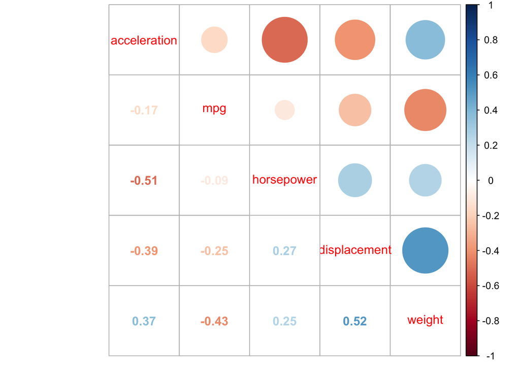

```r
corrplot.mixed(matrix.partial,order="AOE" )
```

Displaying the plots, we can see that partial correlations are closer to zero than ordinary correlations. In this case, this is suggesting that the relationship between the variables of interest could be explained by their common relationships to the explanatory variables upon which we are conditioning.

#### Coefficient of determination

Define a function r2multv for squared multiple correlation coeficients

```r
r2multv<-function(x){
  r2s=1-1/(diag(solve(cov(x)))*diag(cov(x)))
  r2s
}
```

use it on data set “cars_sub”

```r
r2multv(cars_sub)
```

```
##          mpg displacement   horsepower       weight acceleration
##    0.8320842    0.9159490    0.8662318    0.8984768    0.6745925
```

The coefficient of determination of displacement, horsepower, weight and mpg “explained” by the correlation with the other variables are higher than 80%. This means that more than 80% of the variance of these variables is explained by the correlation. In other words an R2 of more than 0.80 means that 80 percent of the variance in these variables is predictable from the others. Concerning the coefficient of determination of acceleration, we have a 0.67, the data is some scattered.

#### The determinant of R

The determinant of the correlation matrix R can be used to explain linear dependence in a dataset. More specifically, we use the effective dependence coefficient.

```r
edc<-function(x){
  p = length(x)
  e = 1-det(cor(x))^{1/(p-1)}
  e
}
edc(cars_sub)
```

```
## [1] 0.7972801
```

From this calculation we see that linear dependencies explain 80% of the variability of the data.

#### Eigen analysis of R

We perform an eigen analyis of the correlcation matrix with the `eigen` function.

```r
eigen(cor(cars_sub))$values
```

```
## [1] 4.08536583 0.64405655 0.12135384 0.09128192 0.05794186
```

As can be seen, most of the variability is explained by the first principle component (PC). The third, fourth, and fifth PC explain very little of the variability of the dataset.